# PART 2

# 薄板の弾性不安定理論

## A18.9 はじめに

薄板は、航空宇宙構造物において非常に一般的かつ重要な構造要素である。なぜなら、そのような構造物の主要なユニットは薄い板パネルで覆われているからである。航空宇宙構造物において圧縮応力を排除することはできないため、どのような応力強度が薄板パネルの座屈を引き起こすかを知ることは重要である。さまざまな荷重系および境界条件のもとでの薄板パネルの座屈に関する方程式は、何年も前に導出されており、設計エンジニアが容易に利用できるようになっている。本書のPart Cでは、薄板構造要素の実用的な設計における多くの座屈方程式の使用を取り上げる。本章の目的は、薄板の不安定性に関する理論、あるいは設計エンジニアによって広く使用されているこれらの座屈方程式がどのように導出されたかを学生に紹介することである。構造要素の不安定性に関する広範で包括的な取り扱いについては、本章の最後にリストされている参考文献のいくつかを参照されたい。

## A18.10 薄板の純粋曲げ

薄板の不安定性の理論を導出するためには、まず薄板の純粋曲げの理論を導出しなければならない。

以下では、解析は微小変形に限定する。曲げが生じる前の板の中央面を $x$ , $y$ とし、その面に垂直な軸を $z$ とする。 $x$ , $y$ 面上の点は、 $z$ 方向に微小変位 $w$ を受け、これを板のたわみと呼ぶ。曲げ後の $x$ 方向および $y$ 方向の中央面の傾きは次のようになる。

$$i_x = \frac{\partial w}{\partial x} , \quad i_y = \frac{\partial w}{\partial y}$$

微小たわみに対しては、梁の曲率で行われたのと同様に、1と比較して $\frac{\partial w}{\partial x}$ , $\frac{\partial y}{\partial y}$ の累乗を省略することにより、中央面の曲率を近似的に求めることができる。したがって、それぞれ $xz$ 面および $yz$ 面に平行な面内における、たわんだ中央面の曲率は次のようになる。

$$\frac{1}{R_x} = -\frac{\partial^2 w}{\partial x^2} , \quad \frac{1}{R_y} = -\frac{\partial^2 w}{\partial y^2} \quad \cdots\cdots\cdots\cdots\cdots (1a)$$

板の問題で使用されるもう一つの量は、以下で与えられる中央面のいわゆる「ねじれ」である。

$$\frac{1}{R_{xy}} = -\frac{\partial^2 w}{\partial x \partial y} \quad \cdots\cdots\cdots\cdots\cdots (1b)$$

ひずみは、中央面の曲率とねじれを用いて表すことができる。角柱状の棒の純粋曲げの場合、曲げられた後も棒の横断面は平面を維持し、たわんだ中立軸に対して垂直を保つように回転するという仮定により、厳密な解が得られた。このような二つの直交する方向の曲げの組み合わせにより、板の純粋曲げが得られる。

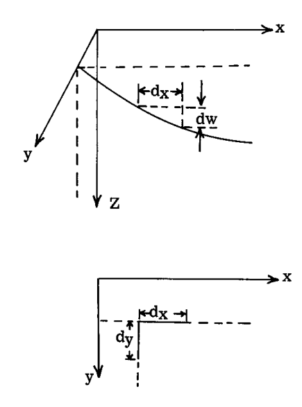

Fig. 1

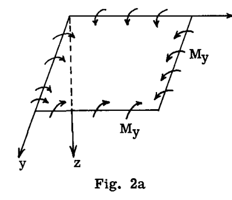

Fig. 2a

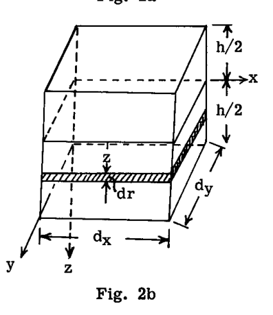

Fig. 2b

図(2a)は、その端部に沿って単位長さあたり一様に分布した曲げモーメント $M_x$ , $M_y$ が載荷された薄い長方形の板を表しているとする。これらのモーメントは、図に示されている方向に作用するとき、すなわち板の上面に圧縮を、下面に引張を生じさせるときに正とみなされる。また、図(2b)を、辺が $dx$ , $dy$ , $t$ の板から切り出された長方形の要素とする。厚さ $t$ は他の寸法に比べて非常に小さいものとする。明らかに、このようなすべての要素の端部における応力状態は図(2a)のそれと同一になる。ここで、要素の側面は曲げの間も平面を維持し、たわんだ中央面に垂直を保つように軸のまわりに回転すると仮定する。対称性のため、中央面は伸縮を受けず、したがって中立面となる。

上述の変形形態の幾何学的関係から、 $x$ , $y$ , $z$ 方向の変位は次のように求めることができる。

中央面上の点 $B$ は、 $z$ 方向に $w$ だけ変位して $B^\prime$ に移動した。面の要素 $dz dy$ は、中央面に垂直な状態を維持するように、たわんだ中央面の傾きに等しい角度だけ回転した。図3を参照されたい。

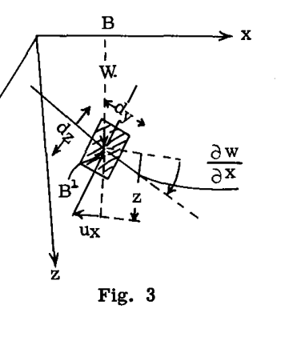

Fig. 3

微小変位に対して、この角度は明らかに $\frac{\partial w}{\partial x}$ に等しい。したがって、中央面から距離 $z$ にある点の $x$ 方向の水平変位 $u_x$ は次のようになる。

$$u_x = -z \frac{\partial w}{\partial x} \quad (\text{マイナス符号は、正の } z \text{ に対して負の変位であることを示す})$$

同様の方法で、 $y$ 方向の変位を求める。完全な変位系は次のようになる。

$$u_x = -z \frac{\partial w}{\partial x} , \quad u_y = -z \frac{\partial w}{\partial y} , \quad u_z = w(x, y) \quad \cdots\cdots (2)$$

対応するひずみは次のようになる。

$$\epsilon_x = -z \frac{\partial^2 w}{\partial x^2} = \frac{z}{R_x} , \quad \epsilon_y = -z \frac{\partial^2 w}{\partial y^2} = \frac{z}{R_y} ,$$

$$\epsilon_{xy} = 2z \frac{\partial^2 w}{\partial x \partial y} = \frac{2z}{R_{xy}} \quad \cdots\cdots\cdots\cdots\cdots (3)$$

板の問題を平面応力問題として扱うため、フックの法則により以下を得る。

$$\sigma_x = \frac{Ez}{1-
u^2} \left( \frac{1}{R_x} +
u \frac{1}{R_y} \right) = -\frac{Ez}{1-
u^2} \left( \frac{\partial^2 w}{\partial x^2} +
u \frac{\partial^2 w}{\partial y^2} \right) \quad \cdots\cdots\cdots (4a)$$

$$\sigma_y = \frac{Ez}{1-
u^2} \left( \frac{1}{R_y} +
u \frac{1}{R_x} \right) = -\frac{Ez}{1-
u^2} \left( \frac{\partial^2 w}{\partial y^2} +
u \frac{\partial^2 w}{\partial x^2} \right) \quad \cdots\cdots\cdots (4b)$$

これらの法線応力は板の厚さにわたって線形に分布している。それらの合力は、それぞれ $M_x$ および $M_y$ に等しくなければならない。

$$\int_{-h/2}^{h/2} \sigma_x z dy dz = M_x dy$$

$$\int_{-h/2}^{h/2} \sigma_y z dx dz = M_y dx$$

式(4)から代入すると、次式が得られる。

$$M_x = -D \left( \frac{\partial^2 w}{\partial x^2} +
u \frac{\partial^2 w}{\partial y^2} \right) \quad \cdots\cdots\cdots\cdots\cdots (5a)$$

$$M_y = -D \left( \frac{\partial^2 w}{\partial y^2} +
u \frac{\partial^2 w}{\partial x^2} \right) \quad \cdots\cdots\cdots\cdots\cdots (5b)$$

ここで、 $D = \frac{E h^3}{12(1- u^2)}$ は板の曲げ剛性である。もし曲げモーメント $M_x$ , $M_y$ に加えて、図(2a)の板の側面に沿って一様に分布したねじりモーメント $M_{xy}$ および $M_{yx}$ が存在する場合、これらは図(2b)の要素の側面に沿った分布剪断応力 $\sigma_{xy}$ , $\sigma_{xz}$ の合力に等しくなければならない。

式(3)から、以下を得る。

$$\sigma_{xy} = \sigma_{yx} = \frac{2Gz}{R_{xy}} = 2Gz \frac{\partial^2 w}{\partial x \partial y} \quad \cdots\cdots\cdots (4c)$$

$$M_{xy} dx = \int_{-h/2}^{h/2} \sigma_{xy} z dx dz , \quad M_{yx} dy = \int_{-h/2}^{h/2} \sigma_{yx} z dy dz$$

$$M_{xy} = M_{yx} = D(1-
u) \frac{\partial^2 w}{\partial x \partial y} \quad \cdots\cdots\cdots\cdots\cdots (5c)$$

式(5)は、板の純粋曲げおよびねじりに対する単位長さあたりのモーメントを与える。

## A18.11 たわみ面の微分方程式

薄板の微小たわみの理論を展開するために、もう一つの仮定を設ける。板の境界において、その端部は板の面内で自由に移動できると仮定する。

したがって、支持による端部での反力は板に垂直である。これらの仮定により、曲げの間の中央面におけるひずみを無視することができる。

中央面の要素 $dx dy$ （図4）を考えてみよう。その端部に沿って、モーメント $M_x$ , $M_y$ , $M_{xy}$ が分布している。これらは、板の厚さに沿って線形に分布する曲げ応力およびねじり応力の合力である（式4および5を参照）。もし板に、上記のモーメントに加えて中央面に垂直な外力が載荷されている場合、図4の要素の側面に作用する垂直剪断力 $Q_x$ , $Q_y$ が存在する。

$$Q_x = \int_{-h/2}^{h/2} \sigma_{xz} dz , \quad Q_y = \int_{-h/2}^{h/2} \sigma_{yz} dz \quad \cdots\cdots (6)$$

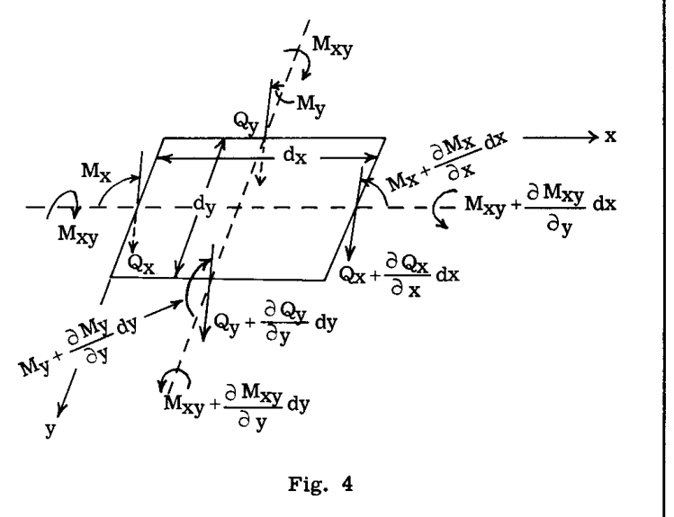

Fig. 4

$q$ を板の上面に垂直に作用する単位面積あたりの横荷重とする。図4の要素の $z$ 方向の力のつり合いを考慮すると、以下が得られる。

$$\frac{\partial Q_x}{\partial x} dx dy + \frac{\partial Q_y}{\partial y} dy dx + q dx dy = 0$$

または、

$$\frac{\partial Q_x}{\partial x} + \frac{\partial Q_y}{\partial y} + q = 0 \quad \cdots\cdots\cdots\cdots\cdots (6a)$$

$x$ 方向に作用するモーメントのつり合いをとると、次式が得られる。

$$\frac{\partial M_{xy}}{\partial x} dx dy - \frac{\partial M_y}{\partial y} dx dy + Q_y dx dy = 0$$

または、

$$\frac{\partial M_{xy}}{\partial x} - \frac{\partial M_y}{\partial y} + Q_y = 0 \quad \cdots\cdots\cdots (6b)$$

$y$ 方向のモーメントのつり合いから、次式が得られる。

$$\frac{\partial M_{xy}}{\partial y} + \frac{\partial M_x}{\partial x} - Q_x = 0 \quad \cdots\cdots\cdots (6c)$$

式(6a, b, c)から $Q_x$ , $Q_y$ を消去することにより、モーメント間のつり合い関係が得られる。

$$\frac{\partial^2 M_x}{\partial x^2} + \frac{\partial^2 M_y}{\partial y^2} - 2 \frac{\partial^2 M_{xy}}{\partial x \partial y} = -q \quad \cdots\cdots\cdots\cdots\cdots (7)$$

この方程式を板のたわみ $w$ を用いて表すために、純粋曲げに対して導出された式(5)が、横荷重を受ける板の場合にも近似的に成り立つという仮定を設ける。この仮定は、曲げに対する剪断力および圧縮応力 $\sigma_z$ の影響を無視することに相当する。これは、梁の曲げに関する工学理論の拡張である。梁の場合と同様に、横荷重を受ける板の曲げに対して良好な近似を与える。

式(4)を式(7)に導入すると、次式が得られる。

$$\frac{\partial^4 w}{\partial x^4} + 2 \frac{\partial^4 w}{\partial x^2 \partial y^2} + \frac{\partial^4 w}{\partial y^4} = \frac{q}{D} \quad \cdots\cdots\cdots\cdots\cdots (8)$$

したがって、板の曲げの問題は、 $w$ について式(8)を積分することに帰着される。変位に関する対応する剪断力は、式(4)および式(6b, c)から求められる。

$$Q_x = \frac{\partial M_{xy}}{\partial y} + \frac{\partial M_x}{\partial x} = -D \frac{\partial}{\partial x} \left( \frac{\partial^2 w}{\partial x^2} + \frac{\partial^2 w}{\partial y^2} \right) \quad \cdots\cdots (9a)$$

$$Q_y = \frac{\partial M_y}{\partial y} - \frac{\partial M_{xy}}{\partial x} = -D \frac{\partial}{\partial y} \left( \frac{\partial^2 w}{\partial x^2} + \frac{\partial^2 w}{\partial y^2} \right) \quad \cdots\cdots (9b)$$

上記の解析は、特定の問題の解を求めるのに十分である。一般的な手順は、与えられた境界変位および力条件を満足する4階の微分方程式(8)の近似解を見つけることである。

## A18.12 薄板の純粋曲げにおけるひずみエネルギー

薄板のひずみエネルギーを評価するにあたり、微小たわみに対して一般に小さい剪断ひずみの寄与は無視するものとする。

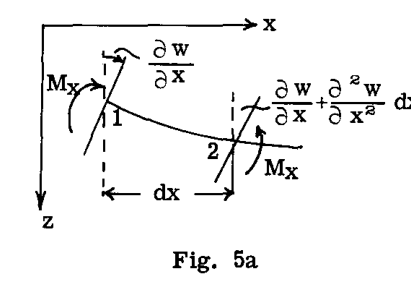

Fig. 5a

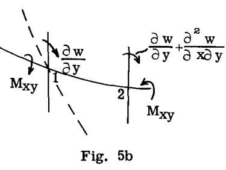

Fig. 5b

板要素に蓄えられたひずみエネルギーは、曲げの間にモーメント $M_x dy$ および $M_y dx$ によって要素になされた仕事を計算することによって得られる。曲げの間、要素の側面は平面を維持するため、 $M_x dy$ によってなされる仕事は、 $M_x dy$ と要素の二つの側面の相対回転角の積の半分をとることによって得られる。 $x$ 方向の曲率は $-\frac{\partial^2 w}{\partial x^2}$ であるため、距離 $dx$ だけ離れた側面1と2の相対回転角は $-\frac{\partial^2 w}{\partial x^2} dx$ となる。

したがって、 $M_x dy$ による仕事は次のようになる。

$$dV_x = -\frac{1}{2} M_x \frac{\partial^2 w}{\partial x^2} dx dy \quad \cdots\cdots\cdots\cdots\cdots (a)$$

同様に、 $M_y dx$ による仕事は次のようになる。

$$dV_y = -\frac{1}{2} M_y \frac{\partial^2 w}{\partial y^2} dx dy \quad \cdots\cdots\cdots\cdots\cdots (b)$$

ねじりモーメント $M_{xy} dy$ も、要素の $x$ 軸まわりの回転に対して仕事をする。二つのセクション1, 2の相対回転角は明らかに $\frac{\partial^2 w}{\partial x \partial y} dx$ である。したがって、 $M_{xy} dy$ によってなされる仕事は次のようになる。

$$dV_{xy} = \frac{1}{2} M_{xy} \frac{\partial^2 w}{\partial x \partial y} dx dy \quad \cdots\cdots\cdots\cdots\cdots (c)$$

また、 $M_{yx} dx = M_{xy} dx$ による仕事は次のようになる。

$$dV_{yx} = \frac{1}{2} M_{xy} \frac{\partial^2 w}{\partial x \partial y} dx dy \quad \cdots\cdots\cdots\cdots\cdots (d)$$

（ねじれは曲げモーメントによって生じる仕事に影響を与えず、曲げもねじりモーメントによって生じる仕事に影響を与えないことに注意されたい）。

したがって、板の単位体積あたりの全ひずみエネルギーは次のようになる。

$$V_0 = \frac{dV_x + dV_y + dV_{xy} + dV_{yx}}{dx dy} =$$

$$\frac{1}{2} \left[ -M_x \frac{\partial^2 w}{\partial x^2} - M_y \frac{\partial^2 w}{\partial y^2} + 2M_{xy} \frac{\partial^2 w}{\partial x \partial y} \right] \quad \cdots\cdots\cdots\cdots\cdots (10)$$

$M_x$ , $M_y$ , $M_{xy}$ を式(5)から変位を用いて代入すると、以下を得る。

$$V_0 = \frac{1}{2} D \left[ \left( \frac{\partial^2 w}{\partial x^2} + \frac{\partial^2 w}{\partial y^2} \right)^2 - 2(1-
u) \left\{ \frac{\partial^2 w}{\partial x^2} \frac{\partial^2 w}{\partial y^2} - \left( \frac{\partial^2 w}{\partial x \partial y} \right)^2 \right\} \right] \quad \cdots\cdots (11)$$

この式は、後で板の座屈問題に関連する板の面内の圧縮荷重の重ね合わせを考慮するときに修正される。

## A18.13 長方形板の曲げ

板の曲げに関する一般的な微分方程式は、セクションC2.3（式8）で与えられた。二つの非常に有用な解法、すなわちフーリエ級数法とエネルギー法が広く用いられてきた。これら両方の手法は、以下において、長方形板およびさまざまな端部支持条件に対して展開される。端部支持条件は次のように分類される。

1. 固定端または埋込端：固定された辺に沿ったたわみはゼロであり、たわんだ中央面に対する接平面は水平である。したがって、たとえば $x$ 軸が固定端と一致する場合、これらの条件は次のようになる。

$$(w)_{y=0} = 0 , \quad \left( \frac{\partial w}{\partial y} \right)_{y=0} = 0 \quad \cdots\cdots\cdots (12a)$$

2. 単純支持端：単純支持された辺に沿ったたわみはゼロであり、この辺に平行な曲げモーメントもゼロである。したがって、板が $x$ 軸に沿って単純支持されている場合、次のようになる。

$$(w)_{y=0} = 0 , \quad (M_y)_{y=0} = -D \left( \frac{\partial^2 w}{\partial y^2} +
u \frac{\partial^2 w}{\partial x^2} \right)_{y=0} = 0 \quad \cdots\cdots (12b)$$

3. 自由端：自由な辺に沿った曲げモーメント、ねじりモーメント、および剪断力はゼロである。したがって、自由な辺が直線 $x = a$ と一致する場合、次のようになる。

$$(M_x)_{x=a} = 0 , \quad (M_{xy})_{x=a} = 0 , \quad (Q_x)_{x=a} = 0$$

しかし、キルヒホッフによって証明されたように、曲げ問題の一意の解を見つけるためには二つの境界条件のみが必要である。彼は、上記の条件の最後の二つの方程式が、一つの条件に置き換えられることを示した。

$$\left( \frac{\partial^3 w}{\partial x^3} + (2-
u) \frac{\partial^3 w}{\partial x \partial y^2} \right)_{x=a} = 0$$

条件 $(M_x)_{x=a} = 0$ を $w$ の項で表すと、自由端に沿った境界条件の最終的な形式が得られる。

$$\left( \frac{\partial^2 w}{\partial x^2} +
u \frac{\partial^2 w}{\partial y^2} \right)_{x=a} = 0 , \quad \left[ \frac{\partial^3 w}{\partial x^3} + (2-
u) \frac{\partial^3 w}{\partial x \partial y^2} \right]_{x=a} = 0 \quad \cdots\cdots (12c)$$

以下では、さまざまな端部条件に対する解を展開する。

### 1. 単純支持された長方形板

図6に示すような、辺が $a$ および $b$ で、軸が $x$ , $y$ の板が、全周にわたって単純支持され、分布荷重 $q = f(x, y)$ が載荷されているとする。

二つの解法が展開される。

#### a) 重フーリエ級数によるナビエ解：

$f(x, y)$ は、常に次のような重三角（フーリエ）級数の形式で表すことができる。

$$q = f(x, y) = \sum_{m=1}^{\infty} \sum_{n=1}^{\infty} a_{mn} \sin \frac{m \pi x}{a} \sin \frac{n \pi y}{b} \quad \cdots\cdots (13a)$$

ここで、

$$a_{mn} = \frac{4}{ab} \int_{0}^{a} \int_{0}^{b} f(x, y) \sin \frac{m \pi x}{a} \sin \frac{n \pi y}{b} dx dy \quad \cdots\cdots (13b)$$

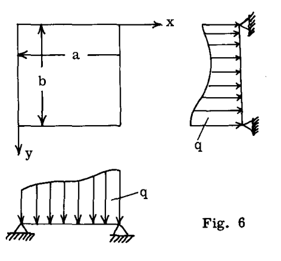

Fig. 6

境界条件は次のとおりである。

$$w = 0 , \quad M_x = 0 \quad \text{at } x = 0, x = a$$

$$w = 0 , \quad M_y = 0 \quad \text{at } y = 0, y = b \quad \text{または}$$

$$(1) \ w = 0 \quad (2) \ \frac{\partial^2 w}{\partial x^2} = 0 \quad \text{at } x = 0, x = a$$

$$(3) \ w = 0 \quad (4) \ \frac{\partial^2 w}{\partial y^2} = 0 \quad \text{at } y = 0, y = b$$

これらの境界条件は、次のように仮定すれば満足される。

$$w = \sum_{m=1}^{\infty} \sum_{n=1}^{\infty} C_{mn} \sin \frac{m \pi x}{a} \sin \frac{n \pi y}{b} \quad \cdots\cdots (14a)$$

式(13)で与えられる $q$ を用いて式(8)に代入すると、以下を得る。

$$\sum_{m=1}^{\infty} \sum_{n=1}^{\infty} C_{mn} \pi^4 \left( \frac{m^2}{a^2} + \frac{n^2}{b^2} \right)^2 \sin \frac{m \pi x}{a} \sin \frac{n \pi y}{b} =$$

$$\frac{1}{D} \sum_{m=1}^{\infty} \sum_{n=1}^{\infty} a_{mn} \sin \frac{m \pi x}{a} \sin \frac{n \pi y}{b} \quad \cdots\cdots (14b)$$

この関係は、次の場合に恒等式となる。

$$C_{mn} = \frac{a_{mn}}{\pi^4 D \left( \frac{m^2}{a^2} + \frac{n^2}{b^2} \right)^2}$$

したがって、次のようになる。

$$w = \frac{1}{\pi^4 D} \sum_{m=1}^{\infty} \sum_{n=1}^{\infty} \frac{a_{mn}}{\left( \frac{m^2}{a^2} + \frac{n^2}{b^2} \right)^2} \sin \frac{m \pi x}{a} \sin \frac{n \pi y}{b} \quad \cdots\cdots (14c)$$

全表面にわたって一様に分布した荷重 $q_0$ の場合、次のようになる。

$$f(x, y) = q_0 = \text{const.}$$

$$a_{mn} = \frac{4q_0}{ab} \int_{0}^{a} \int_{0}^{b} \sin \frac{m \pi x}{a} \cdot \sin \frac{n \pi y}{b} dx dy = \frac{16q_0}{\pi^2 mn} \quad \cdots\cdots (15a)$$

ここで、 $m$ , $n$ はともに奇数である。いずれか一方または両方が偶数の場合は $a_{mn} = 0$ となり、式(14c)に代入すると次のようになる。

$$w = \frac{16q_0}{\pi^6 D} \sum_{m=1,3,5}^{\infty} \sum_{n=1,3,5}^{\infty} \frac{\sin \frac{m \pi x}{a} \sin \frac{n \pi y}{b}}{mn \left( \frac{m^2}{a^2} + \frac{n^2}{b^2} \right)^2} \quad \cdots\cdots (15b)$$

中心における最大たわみは、次のようになる。

$$w_{\max} = \frac{16q_0}{\pi^6 D} \sum_{m=1,3,5}^{\infty} \sum_{n=1,3,5}^{\infty} \frac{(-1)^{\frac{m+n}{2}-1}}{mn \left( \frac{m^2}{a^2} + \frac{n^2}{b^2} \right)^2} \quad \cdots\cdots (15c)$$

これは急速に収束する級数であり、最初の項のみをとることで満足のいく近似が得られる。正方形板の場合、この近似は次のようになる。

$$w_{\max} \approx \frac{4q_0 a^4}{\pi^6 D} = 0.0454 \frac{q_0 a^4}{E h^3} \quad (
u = 0.3 \text{ に対して})$$

これは、厳密解に対して2-1/2%の誤差である。

曲げモーメントおよびねじりモーメントの式は、それほど急速には収束しない。解を改善するために、次のように別の級数解を展開することができる。

#### b) レヴィの代替単一級数解：

この方法は、一様荷重 $q_0 = \text{const.}$ に対して展開される。レヴィは、次の形式の解を提案した。

$$w = \sum_{m=1}^{\infty} Y_m(y) \sin \frac{m \pi x}{a} \quad \cdots\cdots\cdots (16)$$

ここで、 $Y_m$ は $y$ のみの関数である。級数の各項は、境界条件 $w = 0$ , $\frac{\partial^2 w}{\partial x^2} = 0$ at $x = a$ を満足する。 $y = \pm b/2$ において残りの二つの境界条件 $w = 0$ , $\frac{\partial^2 w}{\partial y^2} = 0$ を満足するように $Y_m$ を決定することが残されている。

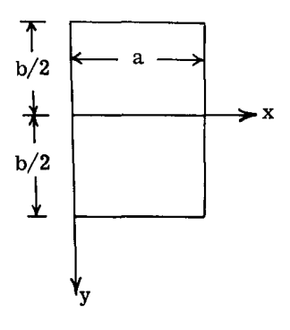

Fig. 7

ここで、対称性から $m = 1, 3, 5, \cdots$ である。

解を次の形式にすると、さらに単純化できる。

$$w = w_1 + w_2 \quad \cdots\cdots\cdots (17a)$$

ここで、

$$w_1 = \frac{q_0}{24D} (x^4 - 2ax^3 + a^3 x) \quad \cdots\cdots\cdots (17b)$$

は、短辺 $x = 0$ , $x = a$ で支持され、二つの長辺で自由な、一様荷重 $q_0$ が載荷された $x$ 方向に非常に長い帯板のたわみである。式(17b)は微分方程式と $x = 0$ , $x = a$ における境界条件を満足するため、次の方程式の解が見つかれば、問題は解決される。

$$\frac{\partial^4 w_2}{\partial x^4} + 2 \frac{\partial^4 w_2}{\partial x^2 \partial y^2} + \frac{\partial^4 w_2}{\partial y^4} = 0 \quad \cdots\cdots (18)$$

ここで、 $w_2$ は式(16)の形式であり、式(17b)の $w_1$ と合わせて、境界条件 $w = 0$ , $\frac{\partial^2 w}{\partial y^2} = 0$ at $y = \pm \frac{b}{2}$ を満足する（図7を参照）。

式(16)を式(18)に代入すると、以下を得る。

$$\sum_{m=1}^{\infty} \left( Y_m^{\text{IV}} - \frac{2m^2 \pi^2}{a^2} Y_m^{\prime\prime} + \frac{m^4 \pi^4}{a^4} Y_m \right) \sin \frac{m \pi x}{a} = 0 \quad \cdots\cdots (19a)$$

この方程式は、次の場合に $x$ のすべての値に対して満足される。

$$Y_m^{\text{IV}} - \frac{2m^2 \pi^2}{a^2} Y_m^{\prime\prime} + \frac{m^4 \pi^4}{a^4} Y_m = 0 \quad \cdots\cdots (19b)$$

式(19b)の一般解は次のようになる。

$$Y_m(y) = \frac{q_0 a^4}{D} \left[ A_m \cosh \frac{m \pi y}{a} + B_m \frac{m \pi y}{a} \sinh \frac{m \pi y}{a} + C_m \sinh \frac{m \pi y}{a} + D_m \frac{m \pi y}{a} \cosh \frac{m \pi y}{a} \right] \quad \cdots\cdots (20)$$

たわみは $x$ 軸に関して対称であるため、 $C_m = D_m = 0$ となる。したがって、次のようになる。

$$w = \frac{q}{24D} (x^4 - 2ax^3 + a^3 x) + \frac{q_0 a^4}{D} \sum_{m=1,3,5}^{\infty} \left( A_m \cosh \frac{m \pi y}{a} + B_m \frac{m \pi y}{a} \sinh \frac{m \pi y}{a} \right) \sin \frac{m \pi x}{a}$$

または、

$$w = \frac{q_0 a^4}{D} \sum_{m=1,3,5}^{\infty} \left( \frac{4}{\pi^5 m^5} + A_m \cosh \frac{m \pi y}{a} + B_m \frac{m \pi y}{a} \sinh \frac{m \pi y}{a} \right) \sin \frac{m \pi x}{a}$$

ここで、 $m = 1, 3, 5, \cdots$ である。この式を境界条件に代入する。

$y = \pm \frac{b}{2}$ に対して $w = 0$ , $\frac{\partial^2 w}{\partial y^2} = 0$ とおくと、以下を得る。

$$A_m \cosh \alpha_m + \alpha_m B_m \sinh \alpha_m + \frac{4}{\pi^5 m^5} = 0$$

$$(A_m + 2B_m) \cosh \alpha_m + \alpha_m B_m \sinh \alpha_m = 0 \quad \cdots\cdots (21a)$$

ここで、 $\alpha_m = m \pi b / 2a$ である。

これらの方程式から、以下が得られる。

$$A_m = -\frac{2(\alpha_m \tanh \alpha_m + 2)}{\pi^5 m^5 \cosh \alpha_m} ,$$

$$B_m = \frac{2}{\pi^5 m^5 \cosh \alpha_m} \quad \cdots\cdots\cdots (21b)$$

したがって、

$$w = \frac{4q_0 a^4}{\pi^5 D} \sum_{m=1,3,5}^{\infty} \frac{1}{m^5} \left[ 1 - \frac{(\alpha_m \tanh \alpha_m + 2) \cosh \frac{2\alpha_m y}{b} - \alpha_m \frac{2y}{b} \sinh \frac{2\alpha_m y}{b}}{2 \cosh \alpha_m} \right] \sin \frac{m \pi x}{a} \quad \cdots\cdots (21c)$$

最大たわみは、中央の $x = \frac{a}{2}$ , $y = 0$ で発生する。

$$w_{\max} = \frac{4q_0 a^4}{\pi^5 D} \sum_{m=1,3,5}^{\infty} \frac{(-1)^{\frac{m-1}{2}}}{m^5} \left( 1 - \frac{\alpha_m \tanh \alpha_m + 2}{2 \cosh \alpha_m} \right) \quad \cdots\cdots (21d)$$

項の最初の級数の合計は、一様荷重を受ける帯板の中央の解（式17b）に対応する。したがって、次のようになる。

$$w_{\max} = \frac{5}{384} \frac{q_0 a^4}{D} - \frac{4q_0 a^4}{\pi^5 D} \sum_{m=1,3,5}^{\infty} \frac{(-1)^{\frac{m-1}{2}}}{m^5} \frac{\alpha_m \tanh \alpha_m + 2}{2 \cosh \alpha_m} \quad \cdots\cdots (21e)$$

この級数は非常に急速に収束する。正方形板 $a/b = 1$ をとると、式(21a)から次のようになる。

$$\alpha_1 = \frac{\pi}{2} , \quad \alpha_3 = \frac{3\pi}{2} \quad \text{など}$$

$$w_{\max} = \frac{5}{384} \frac{q_0 a^4}{D} - \frac{4q_0 a^4}{\pi^5 D} (0.68562 - 0.00025 + \cdots) \approx 0.00406 \frac{q_0 a^4}{D}$$

式(21e)の級数の最初の項のみを考慮すればよいことがわかる。

曲げモーメントは、式(21c)を式(5)に代入することによって求められる。 $x = \frac{a}{2}$ , $y = 0$ における最大曲げモーメントは次のようになる。

$$(M_x)_{\max} = \frac{q_0 a^2}{8} + (1-
u)q_0 a^2 \pi^2 \sum_{m=1,3,5}^{\infty} (-1)^{\frac{m-1}{2}} m^2 (A_m - \frac{2
u}{1-
u} B_m)$$

$$(M_y)_{\max} =
u \frac{q_0 a^2}{8} - (1-
u)q_0 a^2 \pi^2 \sum_{m=1,3,5}^{\infty} (-1)^{\frac{m-1}{2}} m^2 (A_m + \frac{2}{1-
u} B_m) \quad \cdots\cdots (21f)$$

#### c) 仮想仕事の原理による解法

手法(a)の議論から、 $w$ を重フーリエ級数で表すことができる。

$$w = \sum_{m=1}^{\infty} \sum_{n=1}^{\infty} C_{mn} \sin \frac{m \pi x}{a} \sin \frac{n \pi y}{b} \quad \cdots\cdots (22a)$$

係数 $C_{mn}$ は、たわみ面を定義する座標とみなすことができる。仮想変位は次の形式をとる。

$$\delta w = \delta C_{mn} \cdot \sin \frac{m \pi x}{a} \cdot \sin \frac{n \pi y}{b} \quad \cdots\cdots (22b)$$

$$V_1 = \int_{0}^{a} \int_{0}^{b} V_0 dx dy = \frac{\pi^4 ab}{8} D \sum_{m=1}^{\infty} \sum_{n=1}^{\infty} C_{mn}^2 \left( \frac{m^2}{a^2} + \frac{n^2}{b^2} \right)^2 \quad \cdots\cdots (23)$$

ここで、座標 $x = \xi$ , $y = \eta$ の点に集中荷重 $P$ を受ける図6の板のたわみを調べてみよう。たわみの増分によるひずみエネルギーの増分は、次のようになる。

$$\delta w = \delta C_{mn} \sin \frac{m \pi \xi}{a} \sin \frac{n \pi \eta}{b} \quad \cdots\cdots (24a)$$

これは式(23)から求められる。

$$\delta V_1 = \frac{\pi^4 ab}{4} C_{mn} \left( \frac{m^2}{a^2} + \frac{n^2}{b^2} \right)^2 \delta C_{mn} \quad \cdots\cdots (24b)$$

荷重 $P$ の仕事の増分は次のようになる。

$$\delta W = P \delta C_{mn} \sin \frac{m \pi \xi}{a} \sin \frac{n \pi \eta}{b} \quad \cdots\cdots (24c)$$

$\delta V_1 - \delta W = 0$ から、以下を得る。

$$\left[ \frac{\pi^4 ab}{4} C_{mn} \left( \frac{m^2}{a^2} + \frac{n^2}{b^2} \right)^2 - P \sin \frac{m \pi \xi}{a} \cdot \sin \frac{n \pi \eta}{b} \right] \delta C_{mn} = 0$$

$\delta C_{mn}$ は任意であるため、その係数はゼロでなければならない。したがって、次のようになる。

$$C_{mn} = \frac{4P \sin \frac{m \pi \xi}{a} \cdot \sin \frac{n \pi \eta}{b}}{\pi^4 abD \left( \frac{m^2}{a^2} + \frac{n^2}{b^2} \right)^2}$$

$$w = \frac{4P}{\pi^4 abD} \sum_{m=1}^{\infty} \sum_{n=1}^{\infty} \frac{\sin \frac{m \pi \xi}{a} \cdot \sin \frac{n \pi \eta}{b}}{\left( \frac{m^2}{a^2} + \frac{n^2}{b^2} \right)^2} \sin \frac{m \pi x}{a} \cdot \sin \frac{n \pi y}{b} \quad \cdots\cdots (24d)$$

この級数は急速に収束する。正方形板（ $a/b = 1$ ）の場合、

$$w_{\max} = \frac{4Pa^2}{\pi^4 D} \sum_{m=1}^{\infty} \sum_{n=1}^{\infty} \frac{1}{(m^2 + n^2)^2} \quad \cdots\cdots (24e)$$

最初の4つの項だけをとることにより、以下が得られる。

$$w_{\max} \approx 0.01121 \frac{Pa^2}{D}$$

これは、正確な値よりも3-1/2%小さい。

### (2) 二つの対辺が単純支持され、第三の辺が自由、第四の辺が固定または単純支持された長方形板

辺 $x = 0$ および $x = a$ が単純支持され、辺 $y = b$ が自由、辺 $y = 0$ が固定されていると仮定する（図8）。このような場合、境界条件は次のようになる。

$$w = 0 , \quad \frac{\partial^2 w}{\partial x^2} = 0 , \quad \text{for } x = 0, x = a \quad (a)$$

$$w = 0 , \quad \frac{\partial w}{\partial y} = 0 , \quad \text{for } y = 0 \quad (b) \quad \cdots\cdots (25)$$

$$\left[ \frac{\partial^2 w}{\partial y^2} +
u \frac{\partial^2 w}{\partial x^2} \right] = 0 ,$$

$$\left[ \frac{\partial^3 w}{\partial y^3} + (2-
u) \frac{\partial^3 w}{\partial x^2 \partial y} \right] = 0 \quad \text{for } y = b \quad (c)$$

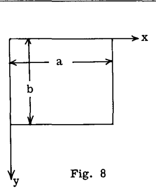

Fig. 8

一様荷重 $q$ の場合を考えてみよう。たわみを次の形式で書く。

$$w = w_1 + w_2 \quad \cdots\cdots\cdots (26a)$$

ここで、 $w_1$ は長さ $a$ の単純支持された帯板のたわみであり、図8の座標系に対して次のように書くことができる（前節のレヴィの手法を参照）。

$$w_1 = \frac{4q a^4}{\pi^5 D} \sum_{m=1,3,5}^{\infty} \frac{1}{m^5} \sin \frac{m \pi x}{a} ,$$

そして $w_2$ は次の級数で表される。

$$w_2 = \sum_{m=1,3,5}^{\infty} Y_m(y) \sin \frac{m \pi x}{a} \quad \cdots\cdots (26c)$$

ここで、 $w_2$ は次の方程式の解である。

$$\frac{\partial^4 w_2}{\partial x^4} + \frac{\partial^4 w_2}{\partial y^4} + 2 \frac{\partial^4 w_2}{\partial x^2 \partial y^2} = 0$$

これは前節と同様に求められる。

$$Y_m = \frac{q a^4}{D} (A_m \cosh \frac{m \pi y}{a} + B_m \frac{m \pi y}{a} \sinh \frac{m \pi y}{a} + C_m \sinh \frac{m \pi y}{a} + D_m \frac{m \pi y}{a} \cosh \frac{m \pi y}{a}) \quad \cdots\cdots (26d)$$

最初の二つの境界条件が $w = w_1 + w_2$ によって恒等的に満足されることは明らかである。係数 $A_m$ , $B_m$ , $C_m$ , $D_m$ は、残りの四つの境界条件を満足するように決定されなければならない。条件(25b)を使用すると、以下を得る。

$$A_m = -\frac{4}{\pi^5 m^5} , \quad C_m = -D_m$$

条件(25c)から、以下を得る。

$$B_m = -\frac{4}{\pi^5 m^5} \cdot \frac{(3+
u)(1-
u) \cosh^2 \beta_m + 2
u \cosh \beta_m - (1-
u) \beta_m \sinh \beta_m - (1-
u)^2}{(3+
u)(1-
u) \cosh^2 \beta_m + (1-
u)^2 \beta_m^2 + (1+
u)^2}$$

$$C_m = -\frac{4}{\pi^5 m^5} \cdot \frac{(3+
u)(1-
u) \sinh \beta_m \cosh \beta_m +
u(1-
u) \sinh \beta_m - (1-
u) \beta_m - (1-
u)^2 \beta_m \cosh \beta_m - (1-
u)^2 \beta_m}{(3+
u)(1-
u) \cosh^2 \beta_m + (1-
u)^2 \beta_m^2 + (1+
u)^2}$$

$$\cdots\cdots (26e)$$

$A_m$ , $B_m$ , $C_m$ , $D_m$ を式(26d)に代入すると、たわみが得られる。最大たわみは、自由端の中央で発生する。

## A18.14 薄板の曲げと引張または圧縮の結合

前ページの平衡微分方程式を展開する際、板は板に垂直な横荷重によって曲げられ、たわみは非常に小さいため中央面の伸縮は無視できると仮定した。ここで、同一平面上の端部荷重のみが作用する場合を考える。